# Rendu MDET

2023-10-16

```r
main_theme = theme_bw()+
  theme(axis.line = element_line(colour = "black"),
        axis.text.x = element_text(colour = "black", size=13),
        axis.text.y = element_text(colour = "black", size=13),
        legend.title = element_text(colour = "black", size=13),
        legend.title.align=0.5,
        legend.text = element_text(colour = "black", size=12),
        axis.title=element_text(size=20))
```

# Définition du modèles

## Formalisme mathématique

Modèle de compétition Lotka-Volterra :

$$\dfrac{dn_i}{dt}=rn_i(1-\dfrac{\sum_{j=1}^Na(x_i,x_j)n_j}{K(x_i)})$$
$$i = 1,2,...,N$$

## Définition des paramètres

# Implémentation du modèle sous R

Sous R, pour des raisons d’optimisation, la proportion de chaque phénotypes sera calculé avec la formule suivente :
$$\dfrac{dN}{dt} = r*N_0*(1-N_0*M)$$
Avec :

- $N_0$ : les valeurs initiales de proportions des phénotypes
- $M$ : la matrice qui regroupe les valeurs des fonctions de compétitions $a$ entre chaque phénotypes et de fitness $K$ égal à :
  $$M_{ij} = \begin{pmatrix}
  \dfrac{a_{11}}{K_1} & \cdots & \dfrac{a_{N1}}{K_1}\\
  \vdots & \space & \vdots \\ \dfrac{a_{1N}}{K_N} & \cdots
  & \dfrac{a_{NN}}{K_N}
  \end{pmatrix}$$

## Création des fonctions nécessaires à la simulation

```r
fonc.K = function(x, K0 = K0, lambda = lambda, x0 = x0){return(
  max(0, 1/(K0-lambda*(x - x0)^2)))}  #Afin de ne pas obtenir de valeur négative, le maximum entre 0 et la valeur de K est retourné.

fonc.a = function(x, y, sigma = sigma){
  return(exp(-(x-y)**2/2*(sigma^2)))
}

EDO_LK <- function(t, y, paraM){
  with(as.list(paraM), { # permet d'éviter de lister les paramètres

  Mat = A * K

  dndt <- r*y*(1-(y%*%Mat)) # Equation différentielle

  return(list(dndt))
  })
}
```

## Définition des valeurs des parmètres

Voici les paramètres dont nous aurons besoin pour définir notre modèle.

```r
# les valeurs des paramètres sont renseignées, elles pourront être réadaptées au besoin

N <- 8 #nombre de traits

# Pour le calcul de la fonction de compétition (a)
sigma <- 0.2

# Pour le calcul de la fonction de fitness (K)
K0 <- 1
lambda <- 1
x0 <- 1/2

# Pour le calcul de la valeur des trais phénotypique
xmin <- 0
xmax <- 1

#Pour le calcul de la proportion d'un phénotype x donné (= résolution de l'EDO)
r <- 0.5
```

Calcul de K et a pour chaque valeur de traits phénotypique :

```r
# création des N valeurs de trait phénotypiques
X = seq(xmin, xmax, length.out = N)

#Création des matrice K et A vides
K = matrix(NA, nrow = length(X), ncol = length(X))
A = matrix(NA, nrow = length(X), ncol = length(X))

for(i in 1:length(X)){
  for(j in 1:length(X)){
    K[i,j] =  fonc.K(x = X[j],K0 = K0, lambda = lambda, x0 = x0)
    A[i,j] = fonc.a(x = X[i], y = X[j], sigma = sigma)
  }
}
```

## Simulations

Pour simuler le comportement du modèle au cours du temps, nous avons besoin de résoudre cette équation différentielle.

### Evolution de la proportion du trait en fonction du temps

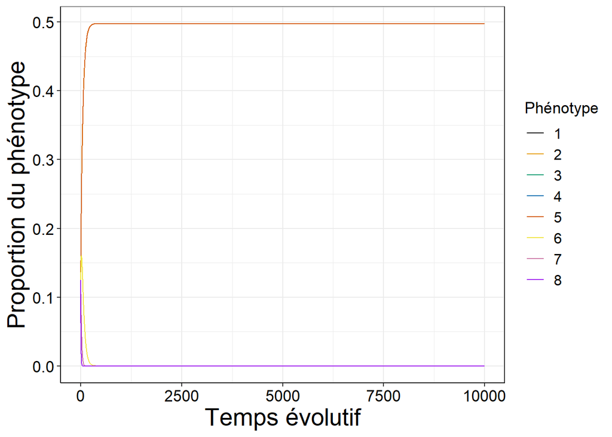

```r
solution %>%
  as_tibble() %>%
  mutate_all(as.numeric) %>%
  pivot_longer(-time, names_to = "Phénotype", values_to = "value") %>%
  ggplot() +
  geom_line(aes(x = time, y = value, color = Phénotype))+
  xlab ("Temps évolutif")+
  ylab ("Proportion du phénotype")+
  scale_colour_manual(values=c("#000000", "#E69F00", "#009E73",
                               "#0072B2", "#D55E00", "#F0E442", "#CC79A7", "purple"))+
  main_theme
```

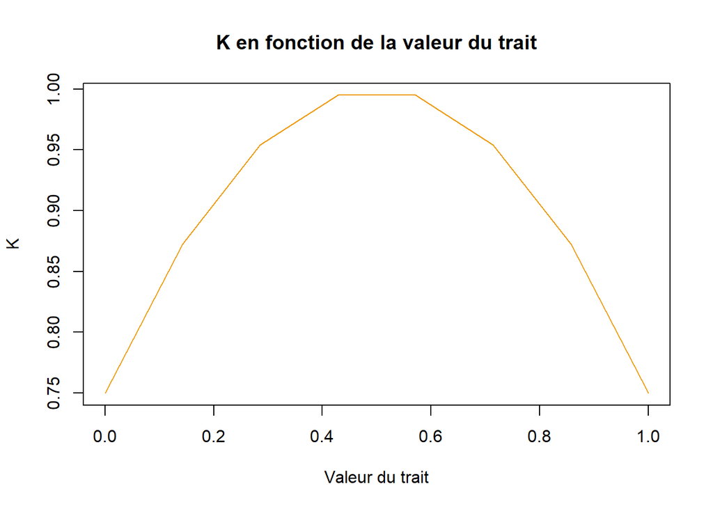

```r
plot(x=X, y=K[1,]^(-1), type='l', col = "orange2", xlab= "Valeur du trait", ylab = "K", main = "K en fonction de la valeur du trait")
```

### Valeur des traits fixé à la fin du temps évolutif

A la fin de la simulation, on s’interesse à savoir quels sont les traits qui ont été fixé et ceux qui ont disparus. Pour cela, on utilise le résultat au temps final de l’équation différentielle. Il s’agit de seuiller sur la proportion du trait puis de représenté les seuls phénotypes ayant été conservés.

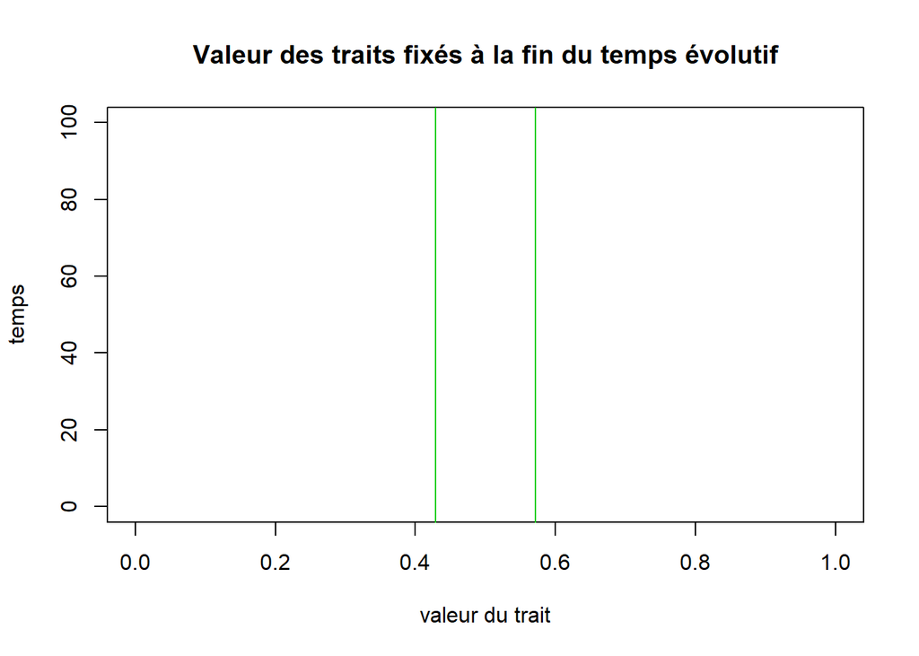

```r
etatfinal = solution[nrow(solution),2:ncol(solution)] #solution de l'équation différentielle au temps final

plot(NULL, ylim = c(0, 100), xlim= c(xmin, xmax), xlab="valeur du trait", ylab="temps", type='l', main ="Valeur des traits fixés à la fin du temps évolutif")
for (rgtrait in 1:length(etatfinal)){
  if (etatfinal[rgtrait] > 0.1){ #seuil
    abline(v = X[rgtrait], col='green3')
  }
}
```

On retrouve les deux traits qui ont été fixés.

# Aprofondissement de l’étude

## Analyse de sensibilité du paramètre $\sigma$

On cherche à étudier l’influence de l’incertitude de $\sigma$ sur le nombre de traits phénotypique sélectionné. C’est un paramètre qui intervient dans le calcul de compétition interspécifique entre deux traits tel que :

$$a(x_i,x_j) = e^{-0.5\dfrac{(x_i-x_j)^2}{\sigma^2_a}}$$

On sait déjà que l’intensité de la compétition va être d’autant plus grande que la distance entre les trait ( $x_i-x_j$ ) est petite. On cherche maintenant à déterminer, pour 8 traits donnés comment la valeur de $\sigma$ influence l’intensité de la compétion interspécifique.

Représentation graphique

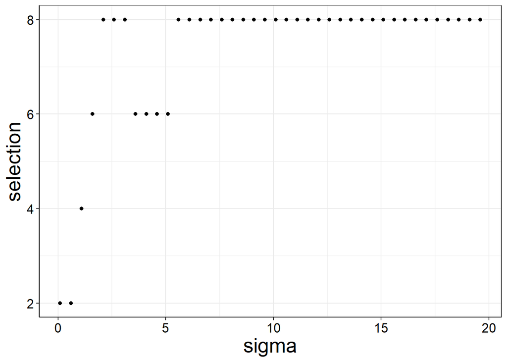

```r
sel_sig = data.frame(sigma = val_sig, selection = selection)

ggplot(data = sel_sig)+
  geom_point(aes(x = sigma, y = selection))+
  main_theme
```

Pour 8 traits données il semble que plus $\sigma$ augmente plus la compétition diminue donc le nombre de traits sélectionnés augmente jusqu’à atteintre le maximum de trait sélectionné (= le nombre de trait de départ).

On faire la même observation en repésentant graphiquement la fonction de compétition $a(x_i,x_j)$ :

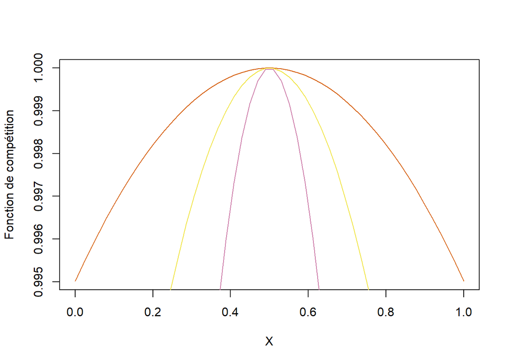

```r
X = seq(from = 0, to = 1, length.out = 50 )

plot(X,fonc.a(x = X, y = 0.5, sigma = 0.2), type = "l", col =  "#D55E00", ylab = ("Fonction de compétition"))
lines(X,fonc.a(x = X, y = 0.5, sigma = 0.4), type = "l", col = "#F0E442")
lines(X,fonc.a(x = X, y = 0.5, sigma = 0.8), type = "l", col = "#CC79A7")
```

On peut voir que plus $\sigma$ est petit plus la fonction de compétition est étendu , donc plus la compétition est importante pour un interval de donné élevé.

## Introduction de Mutations et fixation des traits

Une mutation est introduite dans le modèle. Une fraction de la population va être soumise à cette légère modification de la valeur du trait, avec une probabilité $p$. Nous avons choisi de ne faire que des mutations “à droite”, c’est à dire qu’il n’y a pas de retour en arrière possible, la valeur du trait mute toujours en augmentant. Il s’agit d’une hypothèse forte sans réelle valeur biologique, en effet, l’évolution peut tout à fait faire disparaître une mutation apparue préalablement. Nous nous sommes arrêtées sur cette hypothèse par mesure de simplicité.

### Pour tous les traits d’effectifs initiaux équivalent :

En concervant l’hypothèse qu’à l’origine, la population comporte autant d’individu que de phénotypes possible, voici-ce que l’on observe.

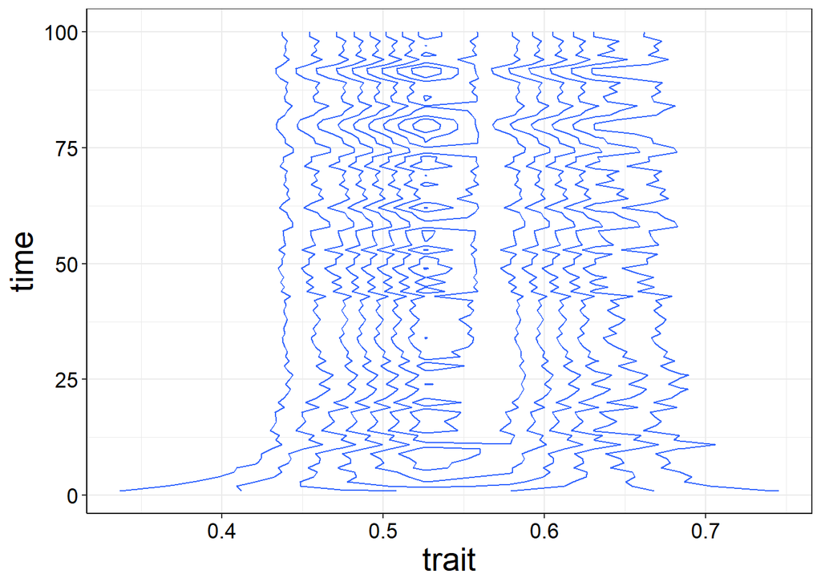

```r
#Initialisation des paramètres pour cette étude
sigma = 0.9
N = 20 #nombre de traits
M = 100 #temps évolutif répétition du temps t.
p = 0.1 #probanilité de mutation
X = seq(xmin, xmax, length.out = N) #valeur des traits
nbarre <- rep(K0/N, N) #Une même portion d'individu partagent chaque trait
temps <- seq(0,100,1)

#Création des matrice K et A (elles restent fixe malgré la mutation)
K = matrix(NA, nrow = length(X), ncol = length(X))
A = matrix(NA, nrow = length(X), ncol = length(X))

for(i in 1:length(X)){
  for(j in 1:length(X)){
    K[i,j] =  fonc.K(x = X[j],K0 = K0, lambda = lambda, x0 = x0)
    A[i,j] = fonc.a(x = X[i], y = X[j], sigma = sigma)
  }
}

paraM = list(r = r, K=K, A=A)

# Création de la matrice qui va contenir les valeurs des phénotypes au cours du temps évolutif M
nTmat = matrix(nrow=M, ncol=length(X))

for(m in 1:M){
  solution <- ode(y = nbarre, times = temps, func = EDO_LK, parms = paraM)
  nT = solution[nrow(solution),2:ncol(solution)]

  for (rgtrait in 1:length(nT)){
    if (nT[rgtrait] > 0.01){
      nTmute <- nT[1:length(nT)-1]*p
      a = runif(1,0,1)

      if (a>0.5){ #mutation à droite
        nT[1:length(nT)-1] = nT[1:length(nT)-1] - nTmute
        nT[2:length(nT)] = nT[2:length(nT)] + nTmute
      }
      #else{ #mutation à gauche
        #nT[1:length(nT)-1] = nT[1:length(nT)-1] + nTmute
        #nT[2:length(nT)] = nT[2:length(nT)] - nTmute
      #}
    }
  }
  nbarre <- nT
  nTmat[m,] <- nT
}


## Affichage graphique

colnames(nTmat) = c(1:N) # on renome pour acceder à l'indice ensuite

nTmat = as.data.frame(nTmat) # on passe la matrice en tableau (obligatoire pour ggplot)

temps_evol <- seq(1, M, 1)
nTmat$time <- temps_evol # ajout du temps

# passage des colonnes en lignes pour permettre l'affichage sous ggplot
nTmat_long = nTmat%>%
  pivot_longer(-time, values_to = "dens", names_to = "phenotype")


nTmat_long$trait = X[ as.numeric(nTmat_long$phenotype)] # étiquette du trait

# Plots
ggplot(nTmat_long)+
  geom_contour(aes(trait, time,  z=dens))+
  scale_fill_gradient2(low = "white" ,
                       high = "red")+
  main_theme
```

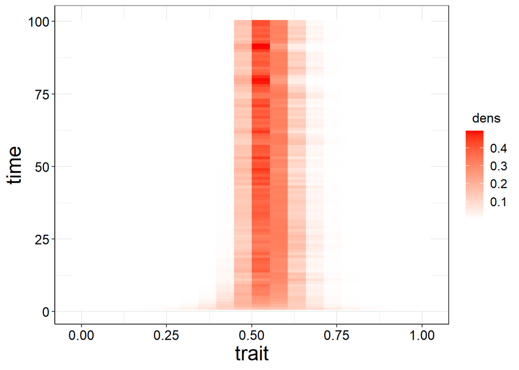

```r
ggplot(nTmat_long)+
  geom_raster(aes(trait, time,  fill=dens))+
  scale_fill_gradient2(low = "white" ,
                       high = "red")+
  main_theme
```

Comme précédemment, les phénotypes qui perdurent sont ceux qui présentent un bon compromis entre valeur selective et compétition.

### Lorsque le trait initial est le trait pour de valeur selective inoptimale :

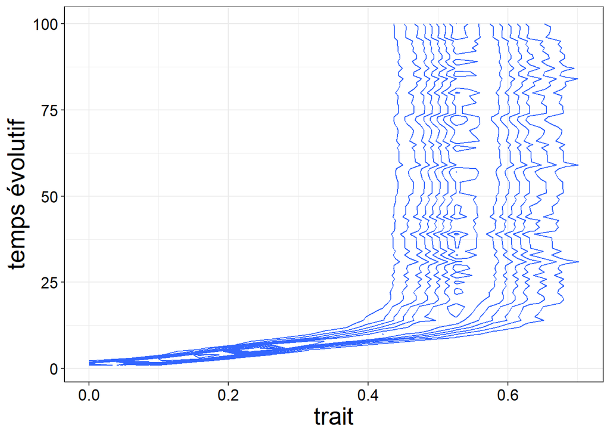

```r
sigma = 0.9

z <- rep(0,N)
z[1] <- 1

nbarre <- z # cette fois, toute la population possède le trait inoptimal à l'état inital.

#Création des matrice K et A (elles restent fixe malgré la mutation)
K = matrix(NA, nrow = length(X), ncol = length(X))
A = matrix(NA, nrow = length(X), ncol = length(X))

for(i in 1:length(X)){
  for(j in 1:length(X)){
    K[i,j] =  fonc.K(x = X[j],K0 = K0, lambda = lambda, x0 = x0)
    A[i,j] = fonc.a(x = X[i], y = X[j], sigma = sigma)
  }
}

paraM = list(r = r, K=K, A=A)

# Création de la matrice qui va contenir les valeurs des phénotypes au cours du temps évolutif M
nTmat = matrix(nrow=M, ncol=length(X))

for(m in 1:M){
  solution <- ode(y = nbarre, times = temps, func = EDO_LK, parms = paraM)
  nT = solution[nrow(solution),2:ncol(solution)]
  for (rgtrait in 1:length(nT)){
    if (nT[rgtrait] > 0.01){
      nTmute <- nT[1:length(nT)-1]*p
      a = runif(1,0,1)
      if (a>0.5){ #mutation à droite
        nT[1:length(nT)-1] = nT[1:length(nT)-1] - nTmute
        nT[2:length(nT)] = nT[2:length(nT)] + nTmute
      }
      #else{ #mutation à gauche
        #nT[1:length(nT)-1] = nT[1:length(nT)-1] + nTmute
        #nT[2:length(nT)] = nT[2:length(nT)] - nTmute
      #}
    }
  }
  nbarre <- nT
  nTmat[m,] <- nT
}



#### et on plot !

colnames(nTmat) = c(1:N) # on renome pour acceder à l'indice ensuite

nTmat = as.data.frame(nTmat) # on passe la matrice en tableau (obligatoire pour ggplot)

temps_evol <- seq(1, M, 1)
nTmat$time <- temps_evol # ajout du temps

# passage des colonnes en lignes pour permettre l'affichage sous ggplot
nTmat_long = nTmat%>%
  pivot_longer(-time, values_to = "dens", names_to = "phenotype")


nTmat_long$trait = X[ as.numeric(nTmat_long$phenotype)] # étiquette du trait

ggplot(nTmat_long)+
  geom_contour(aes(trait, time,  z=dens))+
  scale_fill_gradient2(low = "white" ,
                       high = "red")+
  main_theme+
  ylab("temps évolutif")
```

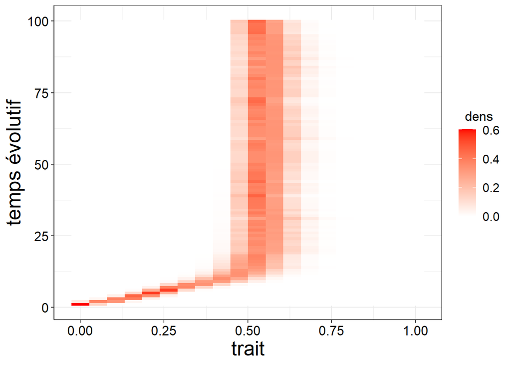

```r
ggplot(nTmat_long)+
  geom_raster(aes(trait, time,  fill=dens))+
  scale_fill_gradient2(low = "white" ,
                       high = "red")+
  main_theme+
  ylab("temps évolutif")
```

### Influence de la valeur de sigma

Lorsque l’on modifie cette valeur de sigma pour lever la pression de compétition, on constate la coexistence de deux phénotypes.

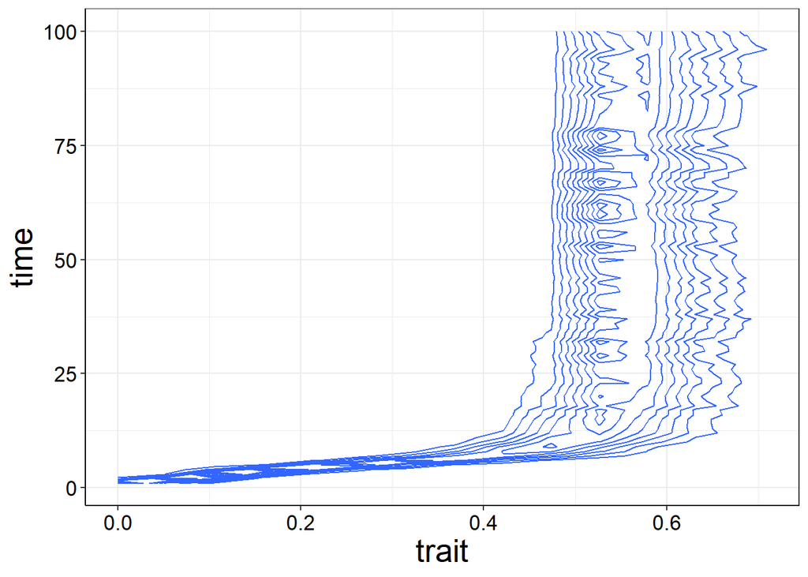

```r
sigma = 0.2

z <- rep(0,N)
z[1] <- 1
nbarre <- z

#Création des matrice K et A (elles restent fixe malgré la mutation)
K = matrix(NA, nrow = length(X), ncol = length(X))
A = matrix(NA, nrow = length(X), ncol = length(X))

for(i in 1:length(X)){
  for(j in 1:length(X)){
    K[i,j] =  fonc.K(x = X[j],K0 = K0, lambda = lambda, x0 = x0)
    A[i,j] = fonc.a(x = X[i], y = X[j], sigma = sigma)
  }
}

paraM = list(r = r, K=K, A=A)

# Création de la matrice qui va contenir les valeurs des phénotypes au cours du temps évolutif M
nTmat = matrix(nrow=M, ncol=length(X))

for(m in 1:M){
  solution <- ode(y = nbarre, times = temps, func = EDO_LK, parms = paraM)
  nT = solution[nrow(solution),2:ncol(solution)]
  for (rgtrait in 1:length(nT)){
    if (nT[rgtrait] > 0.01){
      nTmute <- nT[1:length(nT)-1]*p
      a = runif(1,0,1)
      if (a>0.5){ #mutation à droite
        nT[1:length(nT)-1] = nT[1:length(nT)-1] - nTmute
        nT[2:length(nT)] = nT[2:length(nT)] + nTmute
      }
      #else{ #mutation à gauche
        #nT[1:length(nT)-1] = nT[1:length(nT)-1] + nTmute
        #nT[2:length(nT)] = nT[2:length(nT)] - nTmute
      #}
    }
  }
  nbarre <- nT
  nTmat[m,] <- nT
}



#### et on plot !


colnames(nTmat) = c(1:N) # on renome pour acceder à l'indice ensuite

nTmat = as.data.frame(nTmat)

temps_evol <- seq(1, M, 1)
nTmat$time <- temps_evol # ajout du temps


nTmat_long = nTmat%>%
  pivot_longer(-time, values_to = "dens", names_to = "phenotype")

nTmat_long$trait = X[ as.numeric(nTmat_long$phenotype)] # étiquette du trait



ggplot(nTmat_long)+
  geom_contour(aes(trait, time,  z=dens))+
  scale_fill_gradient2(low = "white" ,
                       high = "red")+
  main_theme
```

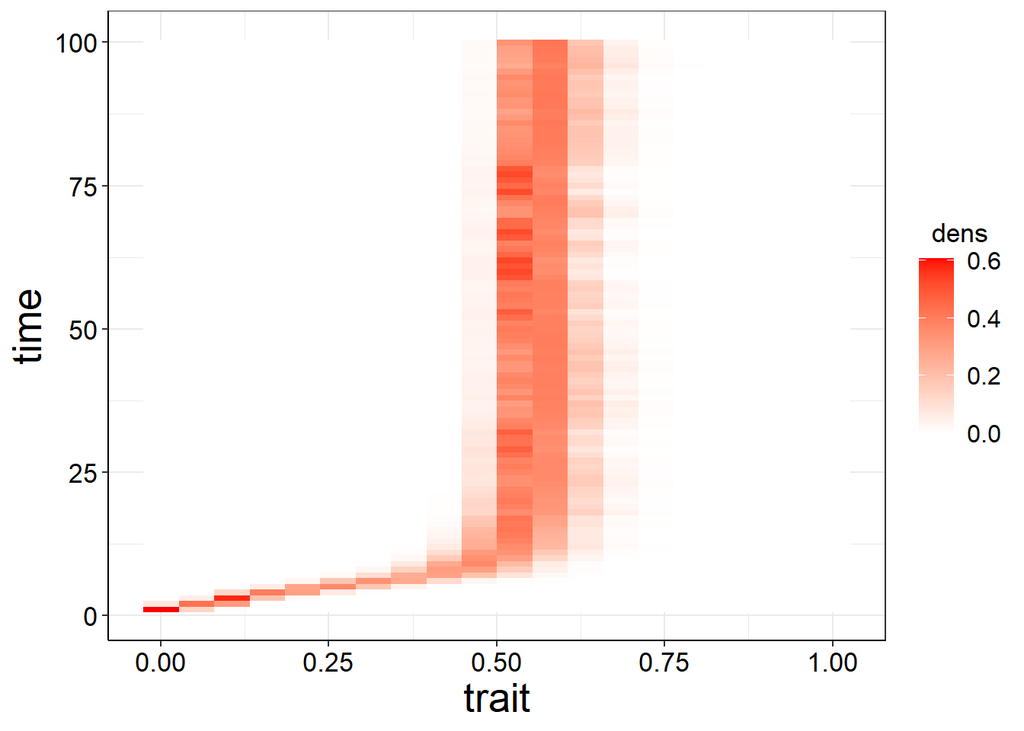

```r
ggplot(nTmat_long)+
  geom_raster(aes(trait, time,  fill=dens))+
  scale_fill_gradient2(low = "white" ,
                       high = "red")+
  main_theme
```

Dans ce cas-ci, deux phénotypes coexistent. Aucun des deux n’est optimal mais il permettent un compromis entre pression de compétition et valeur sélective. Sans être optimaux, ces phénotypes sont viables et autorisent les individus à coexister.